# Notebook 1: Conceptos básicos de Python y series de tiempo con pandas

### Mini-curso de Introducción a herramientas computacionales para Oceanografía Física

#### Oceanografía Física, CICESE

21 de septiembre de 2026

> La parte de fundamentos de Python de este notebook está basada en la lección [Programming with Python](https://swcarpentry.github.io/python-novice-inflammation/) de [Software Carpentry](https://software-carpentry.org/), publicada bajo la [Creative Commons - Attribution License](https://software-carpentry.org/license/). Traducción, adaptación al proyecto del curso y modificaciones por Karina Ramos Musalem.

> Para el trabajo con datos tabulados usaremos [pandas](https://pandas.pydata.org/docs/), una biblioteca de Python para trabajar con datos organizados en tablas y series de tiempo.

Volviendo al caso del curso, María Luisa ya organizó los archivos del proyecto desde la terminal. Ahora puede comenzar a trabajar con los datos. Tenemos dos series de tiempo en archivos CSV: el índice oceánico de El Niño (ONI) y precipitación mensual acumulada en Ensenada. Estos datos fueron proporcionados por la Dra. Marisol García Reyes.

**Pregunta de este notebook:** ¿qué contienen estos archivos y cómo podemos empezar a explorarlos de una forma que después podamos reutilizar?

## Antes de empezar

Al terminar este notebook:

- recordarán qué es una variable y reconocerán algunos tipos de objetos de Python;
- importarán bibliotecas y usarán funciones que viven dentro de ellas;
- leerán archivos CSV con `pandas`;
- seleccionarán columnas, filas y datos que cumplen una condición;
- usarán `if`, `elif` y `else` para tomar decisiones;
- escribirán y usarán una función;
- usarán un ciclo `for` para repetir una operación;
- identificarán datos faltantes (`NaN`);
- producirán una primera visualización de las series de tiempo.

### JupyterLab

Los [Jupyter notebooks](https://jupyter.org/) combinan celdas de código, figuras, ecuaciones y texto. Una celda de código se ejecuta con `Shift` + `Enter`. El orden de ejecución **sí importa**: una variable sólo existe después de ejecutar la celda que la define.

Antes de abrir este notebook, desde la raíz del proyecto:

```
cd enso_baja
conda activate oceanografia
jupyter lab
```

Este notebook debe estar en `notebooks/` y los datos en `data/`. Por eso las rutas que usaremos comienzan con `../data/`: `..` significa *subir un directorio*, como vimos en la sesión de terminal.

## 1. Bibliotecas, objetos y variables

#### Preguntas a responder

1. ¿Qué es una biblioteca de Python y cómo la usamos?
2. ¿Qué guarda una variable?
3. ¿Cómo podemos averiguar qué tipo de objeto tenemos?

#### Objetivos

- Importar bibliotecas usando nombres cortos convencionales.
- Asignar objetos a variables.
- Usar `type()` para inspeccionar objetos.

Python incluye herramientas básicas, pero gran parte de la programación científica se apoya en **bibliotecas**: colecciones de funciones, clases y otros objetos diseñados para realizar tareas relacionadas.

En este proyecto usaremos:

- `numpy` para operaciones numéricas;
- `pandas` para tablas y series de tiempo;
- `matplotlib` para visualización.

```python
import numpy as np
import pandas as pd
import matplotlib.pyplot as plt
```

La instrucción `import pandas as pd` importa la biblioteca `pandas` y le asigna el nombre corto `pd`. Es una convención muy común: otras personas reconocerán inmediatamente qué biblioteca estamos usando.

`pd` también es un objeto de Python:

```python
type(pd)
```

```
module
```

Una **variable** es un nombre que asociamos con un objeto. Por ejemplo, podemos guardar la ruta de nuestro archivo ONI en una variable:

```python
filename = "../data/oni_mensual_1981_2026.csv"

type(filename)
```

```
str
```

`filename` es un `str` (*string* o cadena de caracteres). El signo `=` **asigna** el objeto de la derecha al nombre de la izquierda.

Los nombres de variables pueden contener letras, números y `_`, pero no pueden comenzar con un número y distinguen entre mayúsculas y minúsculas.

> **Ayuda:** en Jupyter puedes consultar la documentación de muchas funciones escribiendo `?funcion`, por ejemplo `?pd.read_csv`, o usando `help(funcion)`.

## 2. Leer nuestro primer archivo CSV

#### Pregunta a responder

¿Cómo representamos en Python una tabla con fechas y valores?

`pandas` utiliza principalmente dos estructuras:

- `DataFrame`: una tabla bidimensional con filas y columnas etiquetadas;
- `Series`: una sola columna de datos con un índice.

Usaremos `pd.read_csv()` para leer un archivo de texto separado por comas. El argumento `parse_dates=["time"]` le indica a pandas que interprete la columna `time` como fechas.

```python
oni = pd.read_csv(filename, parse_dates=["time"])
oni.head()
```

|  | time | oni_degC |
| --- | --- | --- |
| 0 | 1981-09-01 | -0.25 |
| 1 | 1981-10-01 | -0.16 |
| 2 | 1981-11-01 | -0.13 |
| 3 | 1981-12-01 | -0.15 |
| 4 | 1982-01-01 | -0.08 |

`head()` es un **método** del objeto `DataFrame`: una función asociada al propio objeto. La notación `objeto.metodo()` aparecerá constantemente en Python científico.

Inspeccionemos nuestro nuevo objeto.

```python
type(oni)
```

```
pandas.DataFrame
```

```python
oni.columns
```

```
Index(['time', 'oni_degC'], dtype='str')
```

```python
oni.shape
```

```
(540, 2)
```

```python
oni.dtypes
```

```
time        datetime64[us]
oni_degC           float64
dtype: object
```

```python
oni.describe()
```

|  | time | oni_degC |
| --- | --- | --- |
| count | 540 | 540.000000 |
| mean | 2004-02-15 08:00:00 | 0.046185 |
| min | 1981-09-01 00:00:00 | -1.850000 |
| 25% | 1992-11-23 12:00:00 | -0.552500 |
| 50% | 2004-02-15 12:00:00 | -0.075000 |
| 75% | 2015-05-08 18:00:00 | 0.572500 |
| max | 2026-08-01 00:00:00 | 2.750000 |
| std | NaN | 0.871231 |

`shape` contiene el número de filas y columnas. `dtypes` muestra el tipo de dato de cada columna y `describe()` calcula un resumen estadístico de las columnas numéricas.

### Pon en práctica lo que aprendiste

1. ¿Cuántos meses contiene el archivo?
2. ¿Cuál es el valor máximo y mínimo de `oni_degC`?
3. ¿Qué fecha corresponde al valor máximo?

Intenta resolver las dos primeras preguntas usando la información que ya produjo `describe()`. Para la tercera puedes experimentar con `idxmax()`.

**Una posible solución**

```
len(oni)
oni["oni_degC"].min()
oni["oni_degC"].max()

i = oni["oni_degC"].idxmax()
oni.loc[i]
```

## 3. Seleccionar información

#### Preguntas a responder

1. ¿Cómo seleccionamos una columna?
2. ¿Cómo seleccionamos una fila?
3. ¿Cómo seleccionamos sólo los datos que cumplen una condición?

Una columna se selecciona usando su nombre entre corchetes:

```python
oni["oni_degC"]
```

```
0     -0.25
1     -0.16
2     -0.13
3     -0.15
4     -0.08
       ...
535    0.11
536    0.46
537    0.95
538    1.39
539    1.80
Name: oni_degC, Length: 540, dtype: float64
```

El resultado ya no es un `DataFrame` con varias columnas sino una `Series`:

```python
type(oni["oni_degC"])
```

```
pandas.Series
```

Los métodos de pandas nos permiten operar directamente sobre la serie:

```python
oni["oni_degC"].mean()
```

```
np.float64(0.046185185185185176)
```

También podemos seleccionar filas. `iloc` selecciona por **posición** (la primera fila tiene posición `0`):

```python
oni.iloc[0]
```

```
time        1981-09-01 00:00:00
oni_degC                  -0.25
Name: 0, dtype: object
```

`loc` puede seleccionar datos usando etiquetas o una condición booleana. Por ejemplo, la expresión siguiente produce `True` donde ONI es mayor que `0.5` y `False` donde no:

```python
oni["oni_degC"] > 0.5
```

```
0      False
1      False
2      False
3      False
4      False
       ...
535    False
536    False
537     True
538     True
539     True
Name: oni_degC, Length: 540, dtype: bool
```

```python
type(oni["oni_degC"] > 0.5)
```

```
pandas.Series
```

Podemos usar esa serie de valores `True/False` como una máscara para quedarnos únicamente con las filas que cumplen la condición:

```python
oni.loc[oni["oni_degC"] > 0.5]
```

|  | time | oni_degC |
| --- | --- | --- |
| 9 | 1982-06-01 | 0.66 |
| 10 | 1982-07-01 | 0.72 |
| 11 | 1982-08-01 | 0.79 |
| 12 | 1982-09-01 | 1.07 |
| 13 | 1982-10-01 | 1.58 |
| ... | ... | ... |
| 511 | 2024-04-01 | 1.26 |
| 512 | 2024-05-01 | 0.82 |
| 537 | 2026-06-01 | 0.95 |
| 538 | 2026-07-01 | 1.39 |
| 539 | 2026-08-01 | 1.80 |

145 rows × 2 columns

Los operadores de comparación que encontraremos con frecuencia son:

| Operador | Significado |
| --- | --- |
| `>` | mayor que |
| `<` | menor que |
| `>=` | mayor o igual |
| `<=` | menor o igual |
| `==` | igual |
| `!=` | distinto |

Observa que `=` asigna un valor, mientras que `==` compara dos valores.

## 4. Condicionales: tomar decisiones

#### Pregunta a responder

¿Cómo hacemos que un programa realice acciones diferentes dependiendo de los datos?

Los condicionales `if`, `elif` y `else` permiten ejecutar código solamente cuando se cumple una condición.

Para fines didácticos vamos a usar una **clasificación simplificada** de cada valor ONI:

- `ONI >= 0.5`: `"El Niño"`
- `ONI <= -0.5`: `"La Niña"`
- valores intermedios: `"Neutral"`

> **Importante:** esto clasifica valores individuales de la serie para practicar programación. No sustituye los criterios operacionales usados para declarar un episodio El Niño o La Niña.

```python
x = 1.2

if x >= 0.5:
    print("El Niño")
elif x <= -0.5:
    print("La Niña")
else:
    print("Neutral")
```

```
El Niño
```

Python utiliza la **indentación** para indicar qué instrucciones pertenecen a cada bloque. El orden también importa: Python prueba las condiciones de arriba hacia abajo y ejecuta el primer bloque que sea verdadero.

Podríamos cambiar `x` y volver a ejecutar la celda muchas veces, pero copiar y pegar el mismo código no es una buena estrategia. Para reutilizar código necesitamos una **función**.

## 5. Funciones: empaquetar código para reutilizarlo

#### Preguntas a responder

1. ¿Cómo definimos una función?
2. ¿Cuál es la diferencia entre definirla y llamarla?
3. ¿Cómo regresa un resultado?

#### Objetivos

- Definir una función con un parámetro.
- Usar `return` para devolver un resultado.
- Entender por qué una función facilita el mantenimiento y reciclaje del código.

Las funciones nos permiten dar un nombre a una tarea. En lugar de copiar varias veces las mismas líneas, escribimos la lógica una sola vez y la llamamos cada vez que la necesitamos. Esta idea será central cuando transformemos nuestro análisis en un script reproducible.

```python
def enso_phase(oni_value):
    """Clasifica de manera simplificada un valor individual de ONI."""

    if oni_value >= 0.5:
        return "El Niño"
    elif oni_value <= -0.5:
        return "La Niña"
    else:
        return "Neutral"
```

La definición comienza con `def`, seguida del **nombre** de la función y sus **parámetros** entre paréntesis.

```
def nombre(parametro):
    # cuerpo de la función
    return resultado
```

En nuestra función:

- `enso_phase` es el nombre;
- `oni_value` es el parámetro que recibe la función;
- el texto entre comillas triples es el **docstring**, una descripción breve de lo que hace;
- `return` devuelve el resultado.

Definir una función no la ejecuta. Para ejecutarla debemos **llamarla** y darle un argumento:

```python
enso_phase(1.2)
```

```
'El Niño'
```

```python
enso_phase(-0.8)
```

```
'La Niña'
```

Puedes consultar el docstring con:

```python
?enso_phase
```

```
Signature: enso_phase(oni_value)
Docstring: Clasifica de manera simplificada un valor individual de ONI.
File:      /var/folders/r4/hg2wldcj1hjfp_tt15dp3kc80000gn/T/ipykernel_44062/3735144605.py
Type:      function
```

### Pon en práctica lo que aprendiste

¿Qué regresará `enso_phase(0.2)`? ¿Y `enso_phase(0.5)`?

Después modifica temporalmente uno de los límites de la función y comprueba cómo cambia el resultado. Devuélvelo a su valor original antes de continuar.

## 6. Repetir acciones con ciclos o *loops*

#### Pregunta a responder

¿Cómo aplicamos la misma operación a varios valores?

Un ciclo `for` repite un conjunto de instrucciones para cada elemento de una colección. Por ejemplo:

```python
values = [1.2, -0.8, 0.1]

for value in values:
    print(value, enso_phase(value))
```

```
1.2 El Niño
-0.8 La Niña
0.1 Neutral
```

En cada iteración, `value` toma el siguiente elemento de la lista `values`. Igual que en un `if` o en una función, el cuerpo del ciclo está indentado.

La idea general es:

```
for elemento in coleccion:
    haz_algo(elemento)
```

Los ciclos son fundamentales, pero muchas bibliotecas científicas ofrecen operaciones que ya recorren los datos internamente. Cuando existe una operación clara de NumPy, pandas o xarray, suele ser preferible usarla a escribir manualmente un ciclo.

### Aplicar nuestra función a una columna completa

`Series.apply()` llama una función para cada valor de una serie. Así podemos reutilizar `enso_phase()` sobre toda la columna ONI:

```python
oni["phase"] = oni["oni_degC"].apply(enso_phase)

oni.head()
```

|  | time | oni_degC | phase |
| --- | --- | --- | --- |
| 0 | 1981-09-01 | -0.25 | Neutral |
| 1 | 1981-10-01 | -0.16 | Neutral |
| 2 | 1981-11-01 | -0.13 | Neutral |
| 3 | 1981-12-01 | -0.15 | Neutral |
| 4 | 1982-01-01 | -0.08 | Neutral |

```python
oni["phase"].value_counts()
```

```
phase
Neutral    247
La Niña    147
El Niño    146
Name: count, dtype: int64
```

La función contiene la lógica; pandas se encarga de repetirla sobre la serie.

## 7. Segundo CSV: precipitación

Ahora leeremos un segundo archivo con precipitación mensual acumulada en una presa de Ensenada. La estructura es similar, por lo que podemos reutilizar exactamente la misma función `pd.read_csv()`.

```python
rain = pd.read_csv(
    "../data/precipitacion_ensenada_1981_2026.csv",
    parse_dates=["time"]
)

rain.head()
```

|  | time | precip_mm |
| --- | --- | --- |
| 0 | 1981-09-01 | 2.0 |
| 1 | 1981-10-01 | 5.0 |
| 2 | 1981-11-01 | 68.5 |
| 3 | 1981-12-01 | 20.0 |
| 4 | 1982-01-01 | 54.8 |

`info()` resume la estructura del `DataFrame`, incluyendo cuántos valores no nulos hay en cada columna:

```python
rain.info()
```

```
<class 'pandas.DataFrame'>
RangeIndex: 540 entries, 0 to 539
Data columns (total 2 columns):
 #   Column     Non-Null Count  Dtype
---  ------     --------------  -----
 0   time       540 non-null    datetime64[us]
 1   precip_mm  511 non-null    float64
dtypes: datetime64[us](1), float64(1)
memory usage: 8.6 KB
```

En datos observacionales es normal encontrar datos faltantes. Pandas los representa usualmente como `NaN` (*Not a Number*). No debemos confundir un dato faltante con precipitación igual a cero.

```python
rain.isna().sum()
```

```
time          0
precip_mm    29
dtype: int64
```

### Pon en práctica lo que aprendiste

Encuentra los meses para los que no tenemos precipitación.

**Una posible solución**

```
rain.loc[rain["precip_mm"].isna()]
```

## 8. Una primera visualización

pandas puede graficar directamente un `DataFrame` o una `Series`. Sus métodos de gráfica utilizan `matplotlib` internamente.

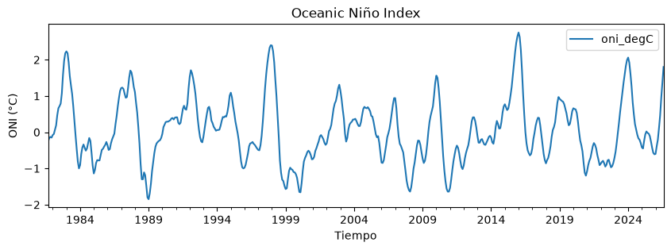

```python
oni.plot(x="time", y="oni_degC", figsize=(10, 3))
plt.ylabel("ONI (°C)")
plt.xlabel("Tiempo")
plt.title("Oceanic Niño Index")
plt.show()
```

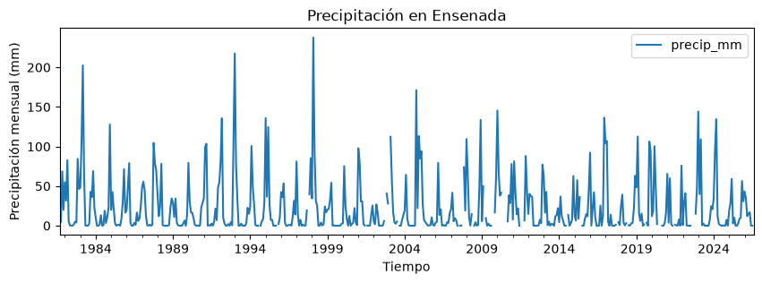

```python
rain.plot(x="time", y="precip_mm", figsize=(10, 3))
plt.ylabel("Precipitación mensual (mm)")
plt.xlabel("Tiempo")
plt.title("Precipitación en Ensenada")
plt.show()
```

Mira las dos series antes de hacer cálculos.

- ONI cambia de manera relativamente suave porque incorpora un promedio de tres meses.
- La precipitación mensual es mucho más intermitente.
- La precipitación presenta una estacionalidad marcada.
- Hay meses sin observación.

**Pregunta para discutir:** ¿tiene sentido comparar directamente estas dos series punto por punto? ¿Qué otras decisiones científicas tendríamos que tomar?

Por ahora no intentaremos contestar completamente esa pregunta. Primero necesitamos incorporar el tercer conjunto de datos del proyecto: la temperatura superficial del mar.

## 9. En resumen

En este notebook:

- importamos bibliotecas con `import`;
- usamos variables para dar nombres a objetos;
- leímos archivos CSV como `DataFrame` con `pd.read_csv()`;
- seleccionamos columnas y filas con `[]`, `iloc` y `loc`;
- usamos comparaciones para construir máscaras booleanas;
- usamos `if`, `elif` y `else` para tomar decisiones;
- escribimos la función `enso_phase()` para reutilizar código;
- usamos un ciclo `for` para repetir una operación;
- aplicamos una función a una `Series`;
- detectamos valores faltantes con `isna()`;
- hicimos gráficas básicas con pandas/matplotlib.

### Para seguir

En el siguiente notebook cambiaremos de tipo de datos. En lugar de una tabla con una serie de tiempo tendremos un campo de SST con dimensiones:

```
tiempo × latitud × longitud
```

Para trabajar con estos datos multidimensionales usaremos `xarray`.